# Assignment 3

Patrick Casanas

2024-11-08

# Text Mining

## Question 1

```r
library(tidytext)
library(dplyr)
library(ggplot2)
library(tidyr)
library(textdata)
abstracts <- read.csv("C:\\Users\\patri\\OneDrive\\Documents\\MPH Sem 3\\Health Data Science\\PM566-labs\\pubmed.csv")
```

```r
word_counts <- abstracts %>%
  unnest_tokens(word, abstract) %>%
  count(term, word, sort=TRUE)

word_counts %>%
  group_by(term) %>%
  slice_max(n, n=5) %>%
  ungroup()
```

```
## # A tibble: 25 × 3
##    term            word      n
##    <chr>           <chr> <int>
##  1 covid           the    9741
##  2 covid           of     7668
##  3 covid           covid  7275
##  4 covid           19     7035
##  5 covid           and    6861
##  6 cystic fibrosis the    2677
##  7 cystic fibrosis of     2304
##  8 cystic fibrosis and    1777
##  9 cystic fibrosis in     1497
## 10 cystic fibrosis to     1011
## # ℹ 15 more rows
```

```r
top_tokens <- word_counts %>%
  group_by(term) %>%
  slice_max(n, n=5) %>%
  ungroup()

top_tokens
```

```
## # A tibble: 25 × 3
##    term            word      n
##    <chr>           <chr> <int>
##  1 covid           the    9741
##  2 covid           of     7668
##  3 covid           covid  7275
##  4 covid           19     7035
##  5 covid           and    6861
##  6 cystic fibrosis the    2677
##  7 cystic fibrosis of     2304
##  8 cystic fibrosis and    1777
##  9 cystic fibrosis in     1497
## 10 cystic fibrosis to     1011
## # ℹ 15 more rows
```

```r
data("stop_words")

stopwords_removed <- word_counts %>%
  anti_join(stop_words, by="word") %>%
  group_by(term) %>%
  slice_max(n, n=5) %>%
  ungroup()

stopwords_removed
```

```
## # A tibble: 25 × 3
##    term            word         n
##    <chr>           <chr>    <int>
##  1 covid           covid     7275
##  2 covid           19        7035
##  3 covid           patients  2293
##  4 covid           disease    943
##  5 covid           pandemic   800
##  6 cystic fibrosis fibrosis   867
##  7 cystic fibrosis cystic     862
##  8 cystic fibrosis cf         625
##  9 cystic fibrosis patients   586
## 10 cystic fibrosis disease    400
## # ℹ 15 more rows
```

Prior to removing stop words, there was nothing really interesting in the terms for COVID and cystic fibrosis since the most prevalent words were insignificant words like “and”, “the”, and “of”. After removing stop words, more interesting words become more prominent. For the COVID search term, the top 5 words include “COVID”, “19”, “patients”, “disease”, and “pandemic. For the cystic fibrosis search term, the top 5 words include”fibrosis”, “cystic”, “cf”, “patients”, and “disease” which are not as interesting as COVID which mentioned the pandemic.

## Question 2

```r
bigrams <- abstracts %>%
  unnest_tokens(bigram, abstract, token="ngrams", n=2) %>%
  count(bigram, sort=TRUE)

top_bigrams <- bigrams %>%
  slice_max(n, n=10)

top_bigrams
```

```
##             bigram    n
## 1         covid 19 6969
## 2           of the 3883
## 3           in the 3418
## 4  prostate cancer 3222
## 5    pre eclampsia 1854
## 6    patients with 1587
## 7         of covid 1519
## 8          and the 1154
## 9           to the 1061
## 10     of prostate  870
```

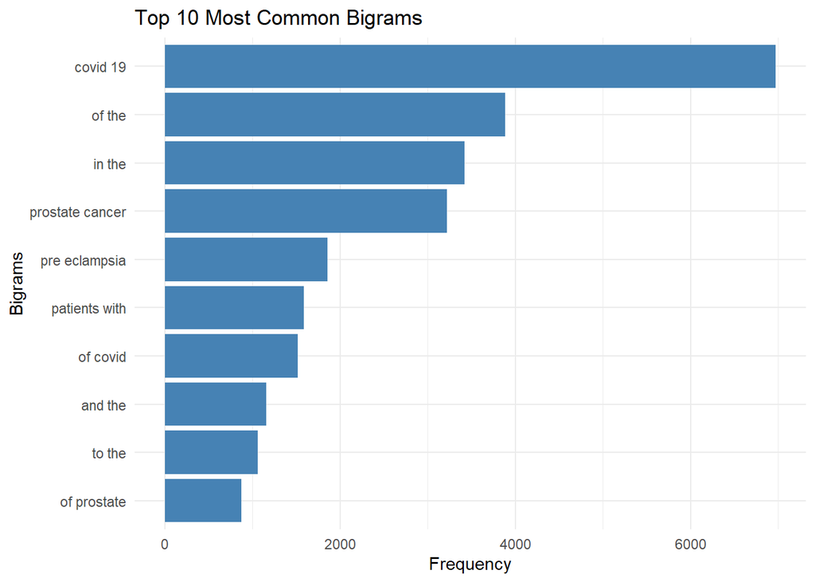

```r
top_bigrams %>%
  ggplot(aes(x = reorder(bigram, n), y = n)) +
  geom_col(fill = "steelblue") +
  coord_flip() +
  labs(
    x = "Bigrams",
    y = "Frequency",
    title = "Top 10 Most Common Bigrams"
  ) +
  theme_minimal()
```

## Question 3

```r
tf_idf_data <- abstracts %>%
  unnest_tokens(word, abstract) %>%
  count (term, word, sort=TRUE) %>%
  bind_tf_idf(word, term, n)

top_tf_idf_words <- tf_idf_data %>%
  group_by(term) %>%
  slice_max(tf_idf, n=5) %>%
  ungroup () %>%
  arrange (term, desc(tf_idf))

top_tf_idf_words
```

```
## # A tibble: 25 × 6
##    term            word            n      tf   idf  tf_idf
##    <chr>           <chr>       <int>   <dbl> <dbl>   <dbl>
##  1 covid           covid        7275 0.0371  1.61  0.0597
##  2 covid           pandemic      800 0.00408 1.61  0.00657
##  3 covid           coronavirus   647 0.00330 1.61  0.00531
##  4 covid           sars          372 0.00190 1.61  0.00305
##  5 covid           cov           334 0.00170 1.61  0.00274
##  6 cystic fibrosis cf            625 0.0127  0.916 0.0117
##  7 cystic fibrosis fibrosis      867 0.0176  0.511 0.00901
##  8 cystic fibrosis cystic        862 0.0175  0.511 0.00896
##  9 cystic fibrosis cftr           86 0.00175 1.61  0.00282
## 10 cystic fibrosis sweat          83 0.00169 1.61  0.00272
## # ℹ 15 more rows
```

The top 5 tokens with the highest TF-IDF values for the search term “covid” are “COVID”, “pandemic”, “coronavirus”, “sars”, and “cov”. These are a lot more interesting than question 1 even after removing stop words but are still just parts of the virus causing COVID-19. Cystic fibrosis has the words “cf”, “fibrosis”, “cystic”, “cftr”, and “sweat”. This again just has words that are part of cystic fibrosis but include the interesting terms of cftr and sweat. CFTR is the gene for cystic fibrosis and sweat is a common symptom. These words are a lot more relevant and useful than any of the terms in Question 1 provided.

# Sentiment Analysis

## Question 1

```r
nrc_sentiments <- get_sentiments("nrc")
```

```r
sentiment_counts <- abstracts %>%
  unnest_tokens(word, abstract) %>%
  inner_join(nrc_sentiments, by="word") %>%
  count(term, sentiment, sort=TRUE)
most_common_sentiment <- sentiment_counts %>%
  group_by(term) %>%
  slice_max(n, n=1) %>%
  ungroup()

most_common_sentiment
```

```
## # A tibble: 5 × 3
##   term            sentiment     n
##   <chr>           <chr>     <int>
## 1 covid           positive   9874
## 2 cystic fibrosis positive   2747
## 3 meningitis      negative   2111
## 4 preeclampsia    positive   8014
## 5 prostate cancer negative   8918
```

```r
sentiment_counts_excluded <- sentiment_counts %>%
  filter(!sentiment %in% c("positive", "negative")) %>%
  group_by(term) %>%
  slice_max(n, n=1) %>%
  ungroup()

sentiment_counts_excluded
```

```
## # A tibble: 5 × 3
##   term            sentiment        n
##   <chr>           <chr>        <int>
## 1 covid           fear          7730
## 2 cystic fibrosis disgust       1714
## 3 meningitis      fear          1510
## 4 preeclampsia    anticipation  4780
## 5 prostate cancer fear          8118
```

Before removing positive and negative sentiment from the list, the most common sentiment are all just positive and negative. After removing them, the most common sentiment for each search term are fear for COVID, disgust for CF, fear for meningitis, anticipation for preeclampsia, and fear for prostate cancer.

## Question 2

```r
afinn <- textdata::lexicon_afinn()

abstracts <- abstracts %>%
  mutate(id=row_number())

positive_scores <- abstracts %>%
  unnest_tokens(word, abstract) %>%
  inner_join(afinn, by = "word") %>%
  group_by(id, term) %>%
  summarize(positive_scores = mean(value, na.rm = TRUE)) %>%
  ungroup() %>%
  filter(!is.na(positive_scores))
```

[output not shown]

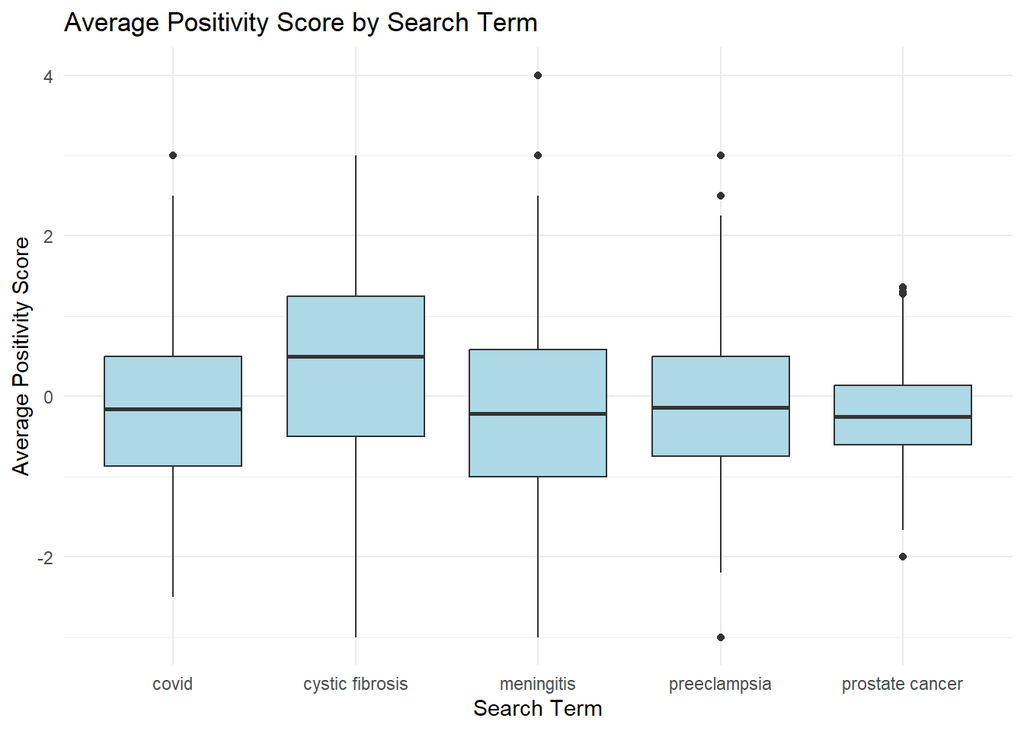

```r
positive_scores %>%
  ggplot(aes(x = term, y = positive_scores)) +
  geom_boxplot(fill = "lightblue") +
  labs(
    x = "Search Term",
    y = "Average Positivity Score",
    title = "Average Positivity Score by Search Term"
  ) +
  theme_minimal()
```

There are none that are noticeably different since all of the boxes overlap. Cystic fibrosis has the highest median average positivity score, and the rest are about even below 0. Cystic fibrosis is the only median that is positive.